# Студент Скрипин Антон ФТ-360008

# Лабораторная - Применение потоковых методов обработки изображений Python -Вариант "A"

### Цели

**Часть 1. Ввод изображения**

**Часть 2: Программирование 2d - convolution (двумерной свертки) изображения**

**Часть 3: Применение двумерной свертки для обработки изображений**

### История/Cценарий

В этой лабораторной работе вы будете исследовать алгоритм двумерной свертки изображений

### Необходимые ресурсы

- 1 ПК с доступом в Интернет
- Библиотеки Python: numpy, matplotlib, scimage
- Файл данных: coins.png

#### Шаг 1. Импорт необходимых библиотек Python.

На этом этапе вы импортируете библиотеки Python, которые потребуются для выполнения практического задания.

```python
#Ячейка №1
import skimage
import os
import matplotlib.pyplot as plt
from skimage import io
from skimage import data
from skimage.viewer import ImageViewer
!pip install opencv-python
import numpy as np
import cv2
import matplotlib.pyplot as plt
```

```
twisted 18.7.0 requires PyHamcrest>=1.9.0, which is not installed.
You are using pip version 10.0.1, however version 18.1 is available.
```

#### Шаг 2. Создание объекта-изображения из файла .png

Используя функцию imread() библиотеки io сформируйте объект-изображение canvas

```python
#Ячейка №2
filename = 'coins.png'
coins = io.imread(filename)
```

#### Шаг 3. Отображение типа объекта-изображения

Используя функцию type() отобразите тип объекта-изображения coins

```python
#Ячейка №3
type(coins)
```

```
numpy.ndarray
```

#### Шаг 4. Отображение структуры объекта-изображения

Используя метод shape отобразите структуру объекта-изображения coins

```python
coins.shape
```

```
(343, 340, 3)
```

#### Шаг 5. Обесцвечивание объекта-изображения.

Создайте объект "gray" с использованием функции cv2.cvtColor для преобразования цветного изображения в изображение с оттенками серого и отобразите его во вьюере ячейки

[figure not shown]

```python
#Ячейка №5
gray = cv2.cvtColor (coins,cv2.COLOR_RGB2GRAY)
plt.imshow(gray, cmap='gray')
plt.show()
```

#### Шаг 6. Определите функцию для преобразования изображения по методу convolution (псевдо-свертка)

Определите функцию, которая формирует выходное изображение (Output) выполняя двумерную свертку входного изображения (input) с ядром (Kernel) 3x3 пиксела по приведенной ниже схеме:

[figure not shown]

```python
#Ячейка №6
def quonvolve2d(image, kernel):
    # This function which takes an image and a kernel
    # and returns the convolution of them
    # Args:
    #   image: a numpy array of size [image_height, image_width].
    #   kernel: a numpy array of size [kernel_height, kernel_width].
    # Returns:
    #   a numpy array of size [image_height, image_width] (convolution output).

    kernel = np.flipud(np.fliplr(kernel))    # Flip the kernel
    output = np.zeros_like(image)            # convolution output
# Add zero padding to the input image
    image_padded = np.zeros((image.shape[0] + 2, image.shape[1] + 2))
    image_padded[1:-1, 1:-1] = image.copy()
# Image normalization
    for x in range(image.shape[1]):     # Loop over every pixel of the image
        for y in range(image.shape[0]):
            if (image_padded[y,x]> 240): image_padded[y,x]= 255
# Image conversion
  # Loop over every pixel of the image
    for x in range(image.shape[1]):     # Loop over every pixel of the image
        for y in range(image.shape[0]):
            # element-wise multiplication of the kernel and the image
            output[y,x]=((kernel*image_padded[y:y+3,x:x+3]).sum())
    return output
```

#### Шаг 7. Проверьте работоспособность функции псевдо-свертки, применив ее к объекту gray с ядром equivalence (Тождество):

**0,0,0**

**0,1,0**

**0,0,0**

отобразите результат во вьюере ячейки

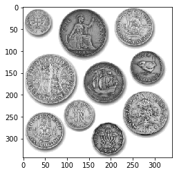

```
[]
```

```python
#Ячейка №7
kernel = np.array([[0,0,0],[0,1,0],[0,0,0]])
image_sharpen = quonvolve2d(gray,kernel)
plt.imshow(image_sharpen, cmap='gray')
plt.show()
viewer = ImageViewer(image_sharpen)
viewer.show()
```

#### Шаг 8. Примените функцию псевдо-свертки объекту gray с ядром sharpen (Выделение граней):

**0,-1,0**

**-1,5,-1**

**0,-1,0**

отобразите результат во вьюере ячейки

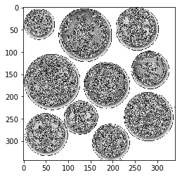

```
[]
```

```python
#Ячейка №8
kernel = np.array([[0,-1,0],[-1,5,-1],[0,-1,0]])
image_sharpen = quonvolve2d(gray,kernel)
plt.imshow(image_sharpen, cmap='gray')
plt.show()
viewer = ImageViewer(image_sharpen)
viewer.show()
```

#### Шаг 9. Примените функцию псевдо-свертки объекту gray с ядром soften (сглаживание):

**1,1,1**

**1,1,1**

**1,1,1**

отобразите результат во вьюере ячейки и оконном вьюере

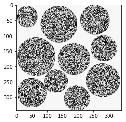

```
[]
```

```python
#Ячейка №9
kernel = np.array([[1,1,1],[1,1,1],[1,1,1]])
image_sharpen = quonvolve2d(gray,kernel)
plt.imshow(image_sharpen, cmap='gray')
plt.show()
viewer = ImageViewer(image_sharpen)
viewer.show()
```

#### Шаг 9а*. Пороговая нормализация объекта-изображения

С помощью функции copy() создайте объект canvas_mask и замените в нем начения выше 150 на 255 (белый). Отобразите нормализованный объект во вьюере ячейки.

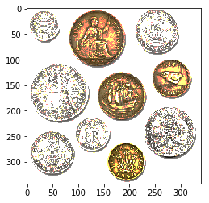

```python
##Лушче было бы указакать к какому объекту применять данное функцую, здесь не совсем очевидно что такое объект canvas
#Ячейка №9а
mask2 = coins > 150
canvas_mask = coins.copy()
canvas_mask[mask2] = 255
plt.imshow(canvas_mask)
plt.show()
```

#### Шаг 10*. Обработка оригинального изображения

Создайте или найдите собственный файл исходного изображения и повторите для него действия, указанные в ячейках 2-5, 7-9 Создайте собственное (или найдите неиспользованное в шагах 7-9) ядро свертки и примените его к оригинальному изображению. Поясните полученные результаты.

[figure not shown]

```python
#Ячейка №10
filename = 'myImage.png'
myImage = io.imread(filename)
type(myImage)
myImage.shape
myGray = cv2.cvtColor (myImage,cv2.COLOR_RGB2GRAY)
plt.imshow(myGray, cmap='gray')
plt.show()
```

Фильтры сглаживания (низкочастотные) сглаживают данные, уменьшая локальное изменение и удаляя шум. Низкочастотный фильтр вычисляет среднее значение для каждой окрестности. Эффект в том, что большие и маленькие значения в каждой окрестности будут усредняться, что уменьшит экстремальные значения данных.

[figure not shown]

```
[]
```

```python
#тип сглаживания - сгладить среднеее арифметическое
kernel = np.array([[0.111,0.111,0.111],[0.111,0.111,0.111],[0.111,0.111,0.111]])
image_sharpen = quonvolve2d(myGray,kernel)
plt.imshow(image_sharpen, cmap='gray' )
plt.show()
viewer = ImageViewer(image_sharpen)
viewer.show()
```

[figure not shown]

```
[]
```

```python
#фильтр ЛАПЛАСА
kernel = np.array([[0,-1,0],[-1,4,-1],[0,-1,0]])
image_sharpen = quonvolve2d(myGray,kernel)
plt.imshow(image_sharpen, cmap='gray' )
plt.show()
viewer = ImageViewer(image_sharpen)
viewer.show()
```

ФИЛЬТР ЛАПЛАСА Фильтры Лапласа часто используются для выявления ребер. Он часто применяется к изображению, которое сначала было сглажено, для уменьшения его чувствительности к шуму.